# Forecasting

Kaz Sakamoto

## Decision Trees Libraries

```r
library(dplyr)
library(ggplot2)
library(readr)
library(tree)

## here we are going to find the root_file
root <- rprojroot::find_rstudio_root_file()
## we are going to set the data file path here
dataDir <- file.path(root, 'Data')
```

## Decision Trees

There is a suspiciously large number floating around the internet, 35,000 decicions on average being made by humans on any give day. While the veracity of this number may be unknown we do in fact make countless unconcious and concious decisions throughout the day.

Beginning in the 1970s, AI researchers have explored the decision-making capabilities of humans and the ability of software to automate these processes. The results were called Expert Systems and by encoding the rules and facts from human experts, computers would soon be able to string together simple yes and no answers into complex tasks like medical diagnosis and mission control for space exploration.

## Twenty Questions

The classic deductive reasoning game is a useful concept for modeling decision trees. The player with the answer will select an object and the other players must guess what the object is with only twenty questions. Well selected questions will greatly improve the teams chances of guessing the right object, and the order of those questions are just as crucial.

The first question in your set should in theory make the biggest split in your decision making. For instance you do not want to start with a very specific question such as “is the object a toaster?”, if the object was a toaster, you did it! But, if it wasn’t, that leaves every other object as a possibility.

## Why Trees?

Trees are another metaphor when we visualize this decision making process. The root or the trunk is the entire population of your data, the first split is going to make the most significant cut into their perspective groupings. These branches can lead to more branches on-and-on.

## Classification Trees

Decision trees can be used to predict classes, for example whether a building permit is going to be accepted or not. Some of the decisions or splits that could be made is the failure rate of the requestor, complexity of project, number of current permits in the building, etc…

## Regression Trees

Trees can also be used for continous data. Decision trees are good at handling non-linear data, so problems such as predicting housing prices can still be made using a tree method. The decision tree input features can also be categorical or continuous which makes this method very flexible.

## Recursive Binary Splitting

To build a tree, you will need to start from the first split. The goal is to make the most homogenous branches. We will have to calculate the accuracy of each split with a cost function, and by doing this recursively you will find an optimal solution for your dataset.

## Cost Function

For Regression, the *Residual Sum of Squares* will be used.

$$RSS = \sum_{i=1}^n (\varepsilon_i)^2 = \sum_{i=1}^n (y_i - \bar{y})^2$$

The split should be the lowest RSS.

For Classification, there are a few ways of selecting the best split.

The Gini imputity is another method that shows “purity” in the regions from a split. To compute Gini impurity for a set of items with $J$ classes, suppose $i\in \{1,2,...,J\}$ , and let $p_{i}$ be the fraction of items labeled with class $i$ in the set.

$$G = \sum_{i=1}^J p_i(1-p_i) = 1-\sum_{i=1}^J p_i^2$$
You 1 - the sum of the probability of the cases. So if you are seeing if a permit passes based on application length greater than 500 words. In the greater than 500 words split, permits passing is 9/10 and not passing is 1/10 it’ll be $1 - (\frac{9}{10})^2 - (\frac{1}{10})^2 = 0.18$. If the permits are less than 500 words then the probabilites of passing 2/6 and not pasing is 4/6 or $1 - (\frac{2}{6})^2 - (\frac{4}{6})^2 = 0.44$. we want Gini Impurity numbers as close to 0 since perfectly classifying one group would be divding 0 which will always result in a 0 value.

## Information Gain

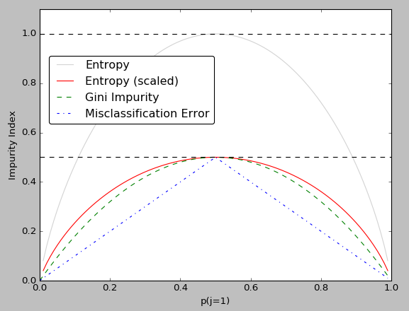

Information Gain

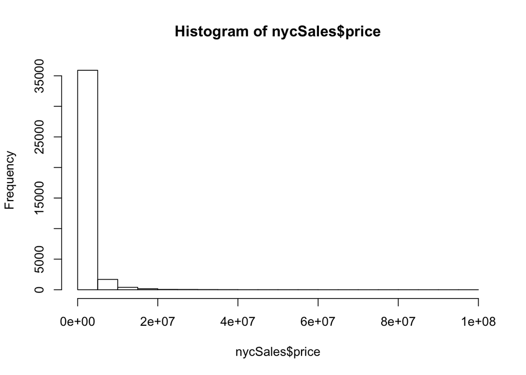

```r
# chr should be factors and make sure numbers are numeric
nycSales <- read_csv(file.path(dataDir, "nycSales.csv")) %>%
    filter(borough %in% c("manhattan", "brooklyn")) %>%
    select(borough, price, num_beds, num_baths,
           num_sqft, type, built_date,monthly_cost) %>%
    mutate(borough = as.factor(borough),
           index = 1:n(),
           num_beds = as.numeric(num_beds),
           num_baths = as.numeric(num_baths),
           type = as.factor(type)) %>%
    filter(complete.cases(.))
hist(nycSales$price)
```

```r
nycSalesTree = tree(borough~.-index, data=nycSales)
summary(nycSalesTree)
```

```
##
## Classification tree:
## tree(formula = borough ~ . - index, data = nycSales)
## Variables actually used in tree construction:
## [1] "monthly_cost" "num_sqft"     "type"
## Number of terminal nodes:  7
## Residual mean deviance:  0.725 = 27760 / 38290
## Misclassification error rate: 0.1603 = 6140 / 38297
```

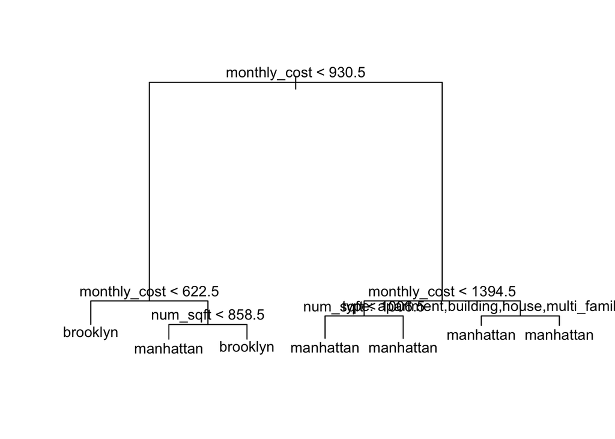

```r
plot(nycSalesTree)
text(nycSalesTree, pretty = 0)
```

```r
set.seed(123)
train=sample_frac(nycSales, size = 0.7)

nycSalesTest = tree(borough~.-index, train)
```

The plot looks a bit different because of the slightly different dataset. Nevertheless, the complexity of the tree looks roughly the same.

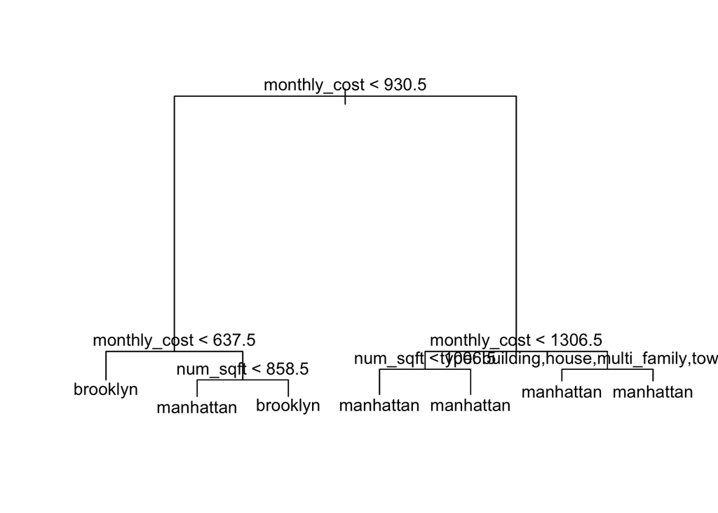

```r
plot(nycSalesTest)
text(nycSalesTest, pretty=0)
```

```r
nycSalesPred <- predict(nycSalesTest, nycSales %>% filter(!index %in% train$index), type="class")

caret::confusionMatrix(nycSalesPred, nycSales %>% filter(!index %in% train$index) %>% .$borough)
```

```
## Confusion Matrix and Statistics
##
##            Reference
## Prediction  brooklyn manhattan
##   brooklyn      1953      1100
##   manhattan      778      7658
##
##                Accuracy : 0.8365
##                  95% CI : (0.8296, 0.8433)
##     No Information Rate : 0.7623
##     P-Value [Acc > NIR] : < 2.2e-16
##
##                   Kappa : 0.5665
##  Mcnemar's Test P-Value : 1.289e-13
##
##             Sensitivity : 0.7151
##             Specificity : 0.8744
##          Pos Pred Value : 0.6397
##          Neg Pred Value : 0.9078
##              Prevalence : 0.2377
##          Detection Rate : 0.1700
##    Detection Prevalence : 0.2657
##       Balanced Accuracy : 0.7948
##
##        'Positive' Class : brooklyn
##
```

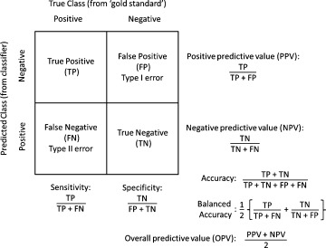

confusion matrix

## Cross Validation

If the tree grows too big, it could be overfitting and “pruning” may help become more generalizeable. we’ll use misclassification error as our criteria.

```r
nycSalesCV = cv.tree(nycSalesTest, FUN = prune.misclass)
nycSalesCV
```

```
## $size
## [1] 7 4 3 2 1
##
## $dev
## [1] 4364 4364 4622 5342 6083
##
## $k
## [1] -Inf    0  269  858 1222
##
## $method
## [1] "misclass"
##
## attr(,"class")
## [1] "prune"         "tree.sequence"
```

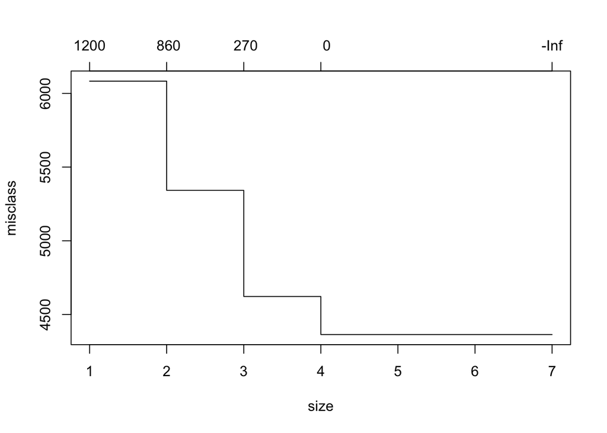

```r
plot(nycSalesCV)
```

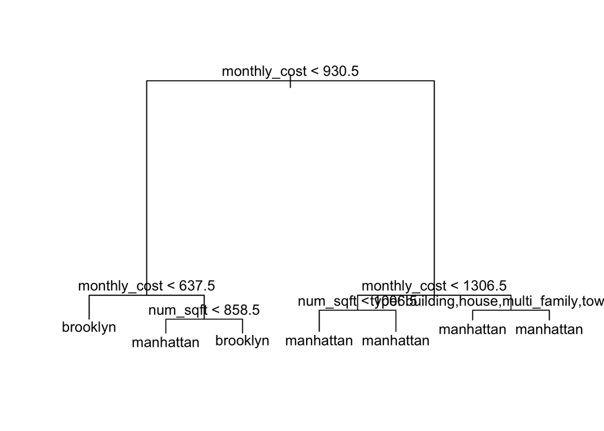

```r
nycSalesPrune = prune.misclass(nycSalesTest, best = 8)
plot(nycSalesPrune)
text(nycSalesPrune, pretty=0)
```

```r
prunePred = predict(nycSalesPrune, nycSales %>% filter(!index %in% train$index), type="class")

caret::confusionMatrix(prunePred, nycSales %>% filter(!index %in% train$index) %>% .$borough)
```

```
## Confusion Matrix and Statistics
##
##            Reference
## Prediction  brooklyn manhattan
##   brooklyn      1953      1100
##   manhattan      778      7658
##
##                Accuracy : 0.8365
##                  95% CI : (0.8296, 0.8433)
##     No Information Rate : 0.7623
##     P-Value [Acc > NIR] : < 2.2e-16
##
##                   Kappa : 0.5665
##  Mcnemar's Test P-Value : 1.289e-13
##
##             Sensitivity : 0.7151
##             Specificity : 0.8744
##          Pos Pred Value : 0.6397
##          Neg Pred Value : 0.9078
##              Prevalence : 0.2377
##          Detection Rate : 0.1700
##    Detection Prevalence : 0.2657
##       Balanced Accuracy : 0.7948
##
##        'Positive' Class : brooklyn
##
```

## Regression Trees

```r
nycSalesReg = tree(price~.-index, train)
summary(nycSalesReg)
```

```
##
## Regression tree:
## tree(formula = price ~ . - index, data = train)
## Variables actually used in tree construction:
## [1] "monthly_cost" "num_sqft"     "borough"
## Number of terminal nodes:  11
## Residual mean deviance:  3.557e+12 = 9.533e+16 / 26800
## Distribution of residuals:
##      Min.   1st Qu.    Median      Mean   3rd Qu.      Max.
## -23040000   -438100   -138700         0    281200  98250000
```

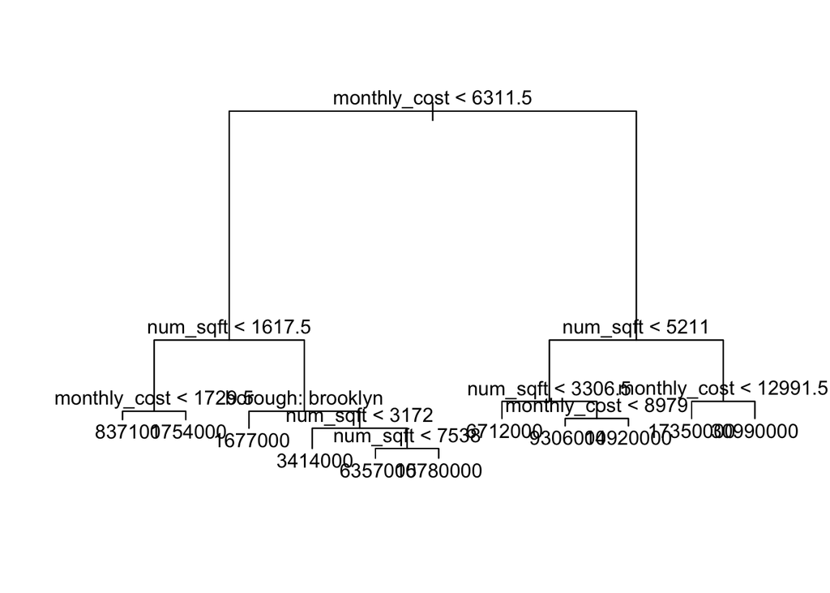

```r
plot(nycSalesReg)
text(nycSalesReg, pretty =  0)
```

```r
regPred = predict(nycSalesReg, nycSales %>% filter(!index %in% train$index))
mse <- mean((nycSales %>% filter(!index %in% train$index) %>% .$price - regPred)^2)
```

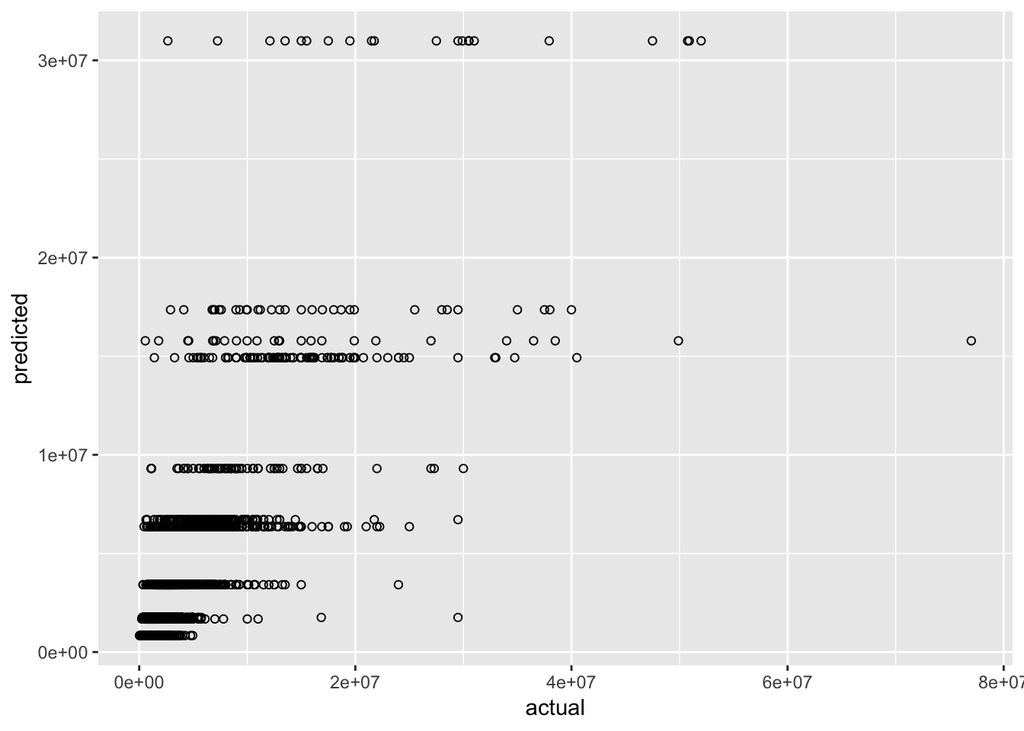

```r
data.frame(actual = nycSales %>% filter(!index %in% train$index) %>% .$price,
           predicted = regPred) %>% ggplot(aes(actual, predicted)) +
    geom_point(shape =1)
```

## Random Forests

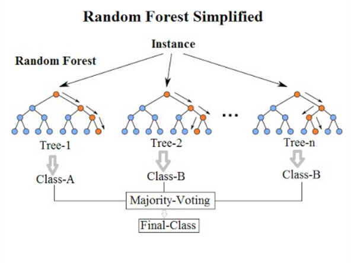

```r
library(randomForest)
nycSalesRF = randomForest(borough~.-index, data = train)
nycSalesRF
```

```
##
## Call:
##  randomForest(formula = borough ~ . - index, data = train)
##                Type of random forest: classification
##                      Number of trees: 500
## No. of variables tried at each split: 2
##
##         OOB estimate of  error rate: 7.66%
## Confusion matrix:
##           brooklyn manhattan class.error
## brooklyn      5464      1187  0.17846940
## manhattan      866     19291  0.04296274
```

Printing out the random forest gives its summary: the # of trees (500 were grown), the out-of-box error rate. The only tuning parameter in a random Forests is the argument called `mtry`, which is the number of variables that are selected at each split of each tree when you make a split. So in our example at each node, only 2 variables are ever presented as choices.

For the `mtry` the default values are different for classification (sqrt(p) where p is number of variables in x) and regression (p/3)

```r
oobErr = double(7)
testErr = double(7)
for(mtry in 1:7){
  fit = randomForest(borough~.-index, train, mtry=mtry, ntree = 350)
  oobErr[mtry] = fit$err.rate[350]
  pred = predict(fit, nycSales %>% filter(!index %in% train$index))
  testErr[mtry] = with(nycSales %>% filter(!index %in% train$index),
                       sum(borough != pred)/nrow(nycSales %>% filter(!index %in% train$index)))
}
```

Basically you just grew 2450 trees (7 times 350). Now let’s make a plot using the matplot command. The test error and the out-of-bag error are binded together to make a 2-column matrix. There are a few other arguments in the matrix, including the plotting character values (pch = 23 means filled diamond), colors (red and blue), type equals both (plotting both points and connecting them with the lines), and name of y-axis (Classification Error Rate). You can also put a legend at the top right corner of the plot.

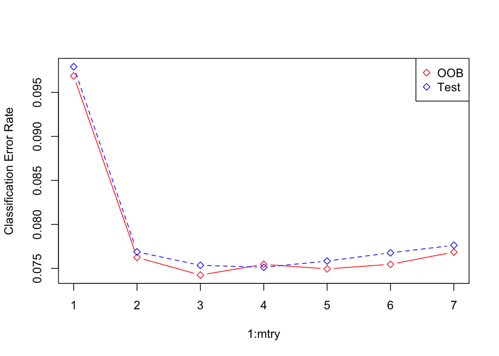

```r
matplot(1:mtry, cbind(testErr, oobErr), pch = 23,
        col = c("red", "blue"), type = "b", ylab="Classification Error Rate")
legend("topright", legend = c("OOB", "Test"), pch = 23, col = c("red", "blue"))
```

## Regression Random Forest

```r
nycPriceRF = randomForest(price~.-index, data = train, ntree = 200)
summary(nycPriceRF)
```

```
##                 Length Class  Mode
## call                4  -none- call
## type                1  -none- character
## predicted       26808  -none- numeric
## mse               200  -none- numeric
## rsq               200  -none- numeric
## oob.times       26808  -none- numeric
## importance          7  -none- numeric
## importanceSD        0  -none- NULL
## localImportance     0  -none- NULL
## proximity           0  -none- NULL
## ntree               1  -none- numeric
## mtry                1  -none- numeric
## forest             11  -none- list
## coefs               0  -none- NULL
## y               26808  -none- numeric
## test                0  -none- NULL
## inbag               0  -none- NULL
## terms               3  terms  call
```

```r
oobErr = double(7)
testErr = double(7)
for(mtry in 1:7){
  fit = randomForest(price~.-index, train, mtry=mtry, ntree = 150)
  oobErr[mtry] = fit$mse[150]
  pred = predict(fit, nycSales %>% filter(!index %in% train$index))
  testErr[mtry] =  with(nycSales %>% filter(!index %in% train$index), mean( (price-pred)^2 ))
}
```

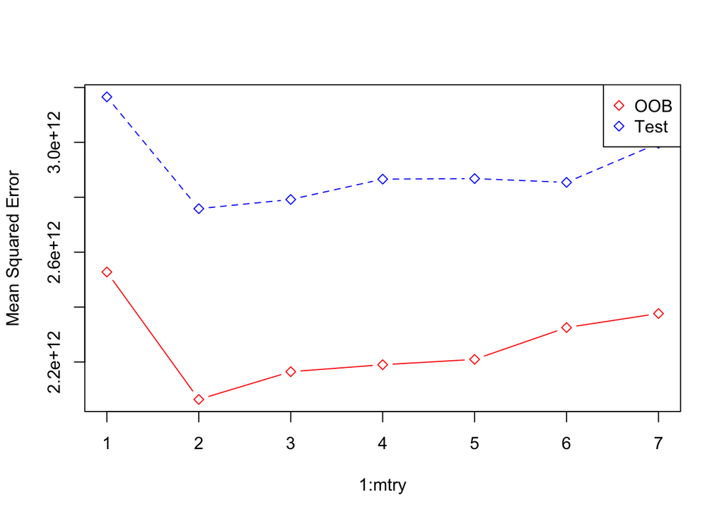

```r
matplot(1:mtry, cbind(testErr, oobErr), pch = 23, col = c("red", "blue"), type = "b", ylab="Mean Squared Error")
legend("topright", legend = c("OOB", "Test"), pch = 23, col = c("red", "blue"))
```